# IS 470 Lab 9: Association Rule Mining

Market basket analysis is used behind the scenes for the recommendation systems used in many brick-and-mortar and online retailers. The learned association rules indicate the combinations of items that are often purchased together. Knowledge of these patterns provides insight into new ways a grocery chain might optimize the inventory, advertise promotions,or organize the physical layout of the store. For instance, if shoppers frequently purchase coffee or orange juice with a breakfast pastry, it may be possible to increase profit by relocating pastries closer to coffee and juice.  
In this lab, we will perform a market basket analysis of transactional data from a grocery store.Our market basket analysis will utilize the purchase data collected from one month of operation at a real-world grocery store. The data contains 9,835 transactions.

### 1. Upload and clean data

```python
# Mounting Google Drive
from google.colab import drive
drive.mount('/content/drive')
```

```python
# Import libraries
! pip install apyori
import pandas as pd
import numpy as np
from csv import reader
import seaborn as sns
from apyori import apriori
```

```python
# Read data line by line
groceries = []
with open('/content/drive/MyDrive/IS470_data/groceries.csv', 'r') as read_obj:
    csv_reader = reader(read_obj)
    for row in csv_reader:
        groceries.append(row)
```

```python
# Inspect the first 5 transactions
groceries[:5]
```

```
[['citrus fruit', 'semi-finished bread', 'margarine', 'ready soups'],
 ['tropical fruit', 'yogurt', 'coffee'],
 ['whole milk'],
 ['pip fruit', 'yogurt', 'cream cheese', 'meat spreads'],
 ['other vegetables',
  'whole milk',
  'condensed milk',
  'long life bakery product']]
```

## 2. Data exploration

```python
# Show the number of transactions
len(groceries)
```

```
9835
```

```python
# Show the number of unique items
flat_list = np.concatenate(groceries).flat
unique_item, item_count = np.unique(flat_list, return_counts=True)
print("number of unique items:", len(unique_item))
```

```
number of unique items: 169
```

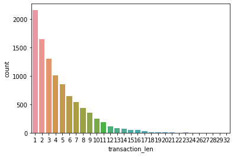

```python
# Plot the distribution of transaction length
transaction_len = []
for transaction in groceries:
  transaction_len.append(len(transaction))
sns.countplot(x = 'transaction_len', data = pd.DataFrame({'transaction_len':transaction_len}))
```

```python
# Examine the absolute frquency of items in descending order
item_frequency = pd.DataFrame({'items':flat_list})
item_frequency.value_counts()
```

```
items
whole milk               2513
other vegetables         1903
rolls/buns               1809
soda                     1715
yogurt                   1372
                         ...
bags                        4
kitchen utensil             4
preservation products       2
baby food                   1
sound storage medium        1
Length: 169, dtype: int64
```

Q1. What are the top 3 most frequent items?

Whole milk, other vegetables, and rolls/buns.

```python
# Examine the relative frquency of items in descending order
item_frequency.value_counts()/len(groceries)
```

```
items
whole milk               0.255516
other vegetables         0.193493
rolls/buns               0.183935
soda                     0.174377
yogurt                   0.139502
                           ...
bags                     0.000407
kitchen utensil          0.000407
preservation products    0.000203
baby food                0.000102
sound storage medium     0.000102
Length: 169, dtype: float64
```

Q2. What are the support values for top 3 most frequent items?  
Whole milk = 0.255516

Other Vegetables = 0.193493

rolls/buns = 0.183935

## 3. Use the apriori algorithm to generate association rules

```python
# Use the apriori command to generate rules with minimal support = 0.01, minimal confidence = 0.3, and max length = 2.
groceries_rules = apriori(groceries, min_support = 0.01, min_confidence = 0.3, max_length=2)
groceries_rules = list(groceries_rules)
```

```python
# Display all rules
all_rules = pd.DataFrame(columns=('LHS','RHS','support','confidence','lift'))
for i in range(len(groceries_rules)):
  for rule_ in groceries_rules[i].ordered_statistics:
    all_rules = all_rules.append({'LHS':','.join(list(rule_.items_base)),'RHS':','.join(list(rule_.items_add)), 'support': groceries_rules[i].support, 'confidence': rule_.confidence, 'lift': rule_.lift}, ignore_index=True)
pd.options.display.max_rows = 999
all_rules
```

|  | LHS | RHS | support | confidence | lift |
| --- | --- | --- | --- | --- | --- |
| 0 | beef | other vegetables | 0.019725 | 0.375969 | 1.943066 |
| 1 | beef | root vegetables | 0.017387 | 0.331395 | 3.040367 |
| 2 | beef | whole milk | 0.021251 | 0.405039 | 1.585180 |
| 3 | berries | other vegetables | 0.010269 | 0.308869 | 1.596280 |
| 4 | berries | whole milk | 0.011795 | 0.354740 | 1.388328 |
| 5 | berries | yogurt | 0.010574 | 0.318043 | 2.279848 |
| 6 | bottled water | whole milk | 0.034367 | 0.310948 | 1.216940 |
| 7 | brown bread | whole milk | 0.025216 | 0.388715 | 1.521293 |
| 8 | butter | other vegetables | 0.020031 | 0.361468 | 1.868122 |
| 9 | butter | whole milk | 0.027555 | 0.497248 | 1.946053 |
| 10 | butter milk | other vegetables | 0.010371 | 0.370909 | 1.916916 |
| 11 | butter milk | whole milk | 0.011591 | 0.414545 | 1.622385 |
| 12 | chicken | other vegetables | 0.017895 | 0.417062 | 2.155439 |
| 13 | chicken | whole milk | 0.017590 | 0.409953 | 1.604411 |
| 14 | chocolate | whole milk | 0.016675 | 0.336066 | 1.315243 |
| 15 | citrus fruit | other vegetables | 0.028876 | 0.348894 | 1.803140 |
| 16 | citrus fruit | whole milk | 0.030503 | 0.368550 | 1.442377 |
| 17 | coffee | whole milk | 0.018709 | 0.322242 | 1.261141 |
| 18 | cream cheese | other vegetables | 0.013726 | 0.346154 | 1.788977 |
| 19 | cream cheese | whole milk | 0.016472 | 0.415385 | 1.625670 |
| 20 | cream cheese | yogurt | 0.012405 | 0.312821 | 2.242412 |
| 21 | curd | other vegetables | 0.017184 | 0.322519 | 1.666829 |
| 22 | curd | whole milk | 0.026131 | 0.490458 | 1.919481 |
| 23 | curd | yogurt | 0.017285 | 0.324427 | 2.325615 |
| 24 | dessert | other vegetables | 0.011591 | 0.312329 | 1.614164 |
| 25 | dessert | whole milk | 0.013726 | 0.369863 | 1.447514 |
| 26 | domestic eggs | other vegetables | 0.022267 | 0.350962 | 1.813824 |
| 27 | domestic eggs | whole milk | 0.029995 | 0.472756 | 1.850203 |
| 28 | frankfurter | rolls/buns | 0.019217 | 0.325862 | 1.771616 |
| 29 | frankfurter | whole milk | 0.020539 | 0.348276 | 1.363029 |
| 30 | frozen vegetables | other vegetables | 0.017794 | 0.369979 | 1.912108 |
| 31 | frozen vegetables | whole milk | 0.020437 | 0.424947 | 1.663094 |
| 32 | fruit/vegetable juice | whole milk | 0.026640 | 0.368495 | 1.442160 |
| 33 | ham | whole milk | 0.011490 | 0.441406 | 1.727509 |
| 34 | hamburger meat | other vegetables | 0.013828 | 0.415902 | 2.149447 |
| 35 | hamburger meat | whole milk | 0.014743 | 0.443425 | 1.735410 |
| 36 | hard cheese | whole milk | 0.010066 | 0.410788 | 1.607682 |
| 37 | hygiene articles | whole milk | 0.012811 | 0.388889 | 1.521975 |
| 38 | long life bakery product | whole milk | 0.013523 | 0.361413 | 1.414444 |
| 39 | margarine | other vegetables | 0.019725 | 0.336806 | 1.740663 |
| 40 | margarine | whole milk | 0.024199 | 0.413194 | 1.617098 |
| 41 | napkins | whole milk | 0.019725 | 0.376699 | 1.474268 |
| 42 | newspapers | whole milk | 0.027351 | 0.342675 | 1.341110 |
| 43 | oil | whole milk | 0.011286 | 0.402174 | 1.573968 |
| 44 | onions | other vegetables | 0.014235 | 0.459016 | 2.372268 |
| 45 | onions | whole milk | 0.012100 | 0.390164 | 1.526965 |
| 46 | pip fruit | other vegetables | 0.026131 | 0.345430 | 1.785237 |
| 47 | pork | other vegetables | 0.021657 | 0.375661 | 1.941476 |
| 48 | root vegetables | other vegetables | 0.047382 | 0.434701 | 2.246605 |
| 49 | sugar | other vegetables | 0.010778 | 0.318318 | 1.645119 |
| 50 | tropical fruit | other vegetables | 0.035892 | 0.342054 | 1.767790 |
| 51 | whipped/sour cream | other vegetables | 0.028876 | 0.402837 | 2.081924 |
| 52 | white bread | other vegetables | 0.013726 | 0.326087 | 1.685268 |
| 53 | other vegetables | whole milk | 0.074835 | 0.386758 | 1.513634 |
| 54 | yogurt | other vegetables | 0.043416 | 0.311224 | 1.608457 |
| 55 | pastry | whole milk | 0.033249 | 0.373714 | 1.462587 |
| 56 | pip fruit | whole milk | 0.030097 | 0.397849 | 1.557043 |
| 57 | pork | whole milk | 0.022166 | 0.384480 | 1.504719 |
| 58 | sausage | rolls/buns | 0.030605 | 0.325758 | 1.771048 |
| 59 | rolls/buns | whole milk | 0.056634 | 0.307905 | 1.205032 |
| 60 | root vegetables | whole milk | 0.048907 | 0.448694 | 1.756031 |
| 61 | sausage | whole milk | 0.029893 | 0.318182 | 1.245252 |
| 62 | sliced cheese | whole milk | 0.010778 | 0.439834 | 1.721356 |
| 63 | sugar | whole milk | 0.015048 | 0.444444 | 1.739400 |
| 64 | tropical fruit | whole milk | 0.042298 | 0.403101 | 1.577595 |
| 65 | waffles | whole milk | 0.012710 | 0.330688 | 1.294196 |
| 66 | whipped/sour cream | whole milk | 0.032232 | 0.449645 | 1.759754 |
| 67 | white bread | whole milk | 0.017082 | 0.405797 | 1.588147 |
| 68 | yogurt | whole milk | 0.056024 | 0.401603 | 1.571735 |

Q3. How many rules are generated?  
69

```python
# Display all rules sorted by confidence levels
all_rules.sort_values(by = 'confidence', ascending = False)
```

|  | LHS | RHS | support | confidence | lift |
| --- | --- | --- | --- | --- | --- |
| 9 | butter | whole milk | 0.027555 | 0.497248 | 1.946053 |
| 22 | curd | whole milk | 0.026131 | 0.490458 | 1.919481 |
| 27 | domestic eggs | whole milk | 0.029995 | 0.472756 | 1.850203 |
| 44 | onions | other vegetables | 0.014235 | 0.459016 | 2.372268 |
| 66 | whipped/sour cream | whole milk | 0.032232 | 0.449645 | 1.759754 |
| 60 | root vegetables | whole milk | 0.048907 | 0.448694 | 1.756031 |
| 63 | sugar | whole milk | 0.015048 | 0.444444 | 1.739400 |
| 35 | hamburger meat | whole milk | 0.014743 | 0.443425 | 1.735410 |
| 33 | ham | whole milk | 0.011490 | 0.441406 | 1.727509 |
| 62 | sliced cheese | whole milk | 0.010778 | 0.439834 | 1.721356 |
| 48 | root vegetables | other vegetables | 0.047382 | 0.434701 | 2.246605 |
| 31 | frozen vegetables | whole milk | 0.020437 | 0.424947 | 1.663094 |
| 12 | chicken | other vegetables | 0.017895 | 0.417062 | 2.155439 |
| 34 | hamburger meat | other vegetables | 0.013828 | 0.415902 | 2.149447 |
| 19 | cream cheese | whole milk | 0.016472 | 0.415385 | 1.625670 |
| 11 | butter milk | whole milk | 0.011591 | 0.414545 | 1.622385 |
| 40 | margarine | whole milk | 0.024199 | 0.413194 | 1.617098 |
| 36 | hard cheese | whole milk | 0.010066 | 0.410788 | 1.607682 |
| 13 | chicken | whole milk | 0.017590 | 0.409953 | 1.604411 |
| 67 | white bread | whole milk | 0.017082 | 0.405797 | 1.588147 |
| 2 | beef | whole milk | 0.021251 | 0.405039 | 1.585180 |
| 64 | tropical fruit | whole milk | 0.042298 | 0.403101 | 1.577595 |
| 51 | whipped/sour cream | other vegetables | 0.028876 | 0.402837 | 2.081924 |
| 43 | oil | whole milk | 0.011286 | 0.402174 | 1.573968 |
| 68 | yogurt | whole milk | 0.056024 | 0.401603 | 1.571735 |
| 56 | pip fruit | whole milk | 0.030097 | 0.397849 | 1.557043 |
| 45 | onions | whole milk | 0.012100 | 0.390164 | 1.526965 |
| 37 | hygiene articles | whole milk | 0.012811 | 0.388889 | 1.521975 |
| 7 | brown bread | whole milk | 0.025216 | 0.388715 | 1.521293 |
| 53 | other vegetables | whole milk | 0.074835 | 0.386758 | 1.513634 |
| 57 | pork | whole milk | 0.022166 | 0.384480 | 1.504719 |
| 41 | napkins | whole milk | 0.019725 | 0.376699 | 1.474268 |
| 0 | beef | other vegetables | 0.019725 | 0.375969 | 1.943066 |
| 47 | pork | other vegetables | 0.021657 | 0.375661 | 1.941476 |
| 55 | pastry | whole milk | 0.033249 | 0.373714 | 1.462587 |
| 10 | butter milk | other vegetables | 0.010371 | 0.370909 | 1.916916 |
| 30 | frozen vegetables | other vegetables | 0.017794 | 0.369979 | 1.912108 |
| 25 | dessert | whole milk | 0.013726 | 0.369863 | 1.447514 |
| 16 | citrus fruit | whole milk | 0.030503 | 0.368550 | 1.442377 |
| 32 | fruit/vegetable juice | whole milk | 0.026640 | 0.368495 | 1.442160 |
| 8 | butter | other vegetables | 0.020031 | 0.361468 | 1.868122 |
| 38 | long life bakery product | whole milk | 0.013523 | 0.361413 | 1.414444 |
| 4 | berries | whole milk | 0.011795 | 0.354740 | 1.388328 |
| 26 | domestic eggs | other vegetables | 0.022267 | 0.350962 | 1.813824 |
| 15 | citrus fruit | other vegetables | 0.028876 | 0.348894 | 1.803140 |
| 29 | frankfurter | whole milk | 0.020539 | 0.348276 | 1.363029 |
| 18 | cream cheese | other vegetables | 0.013726 | 0.346154 | 1.788977 |
| 46 | pip fruit | other vegetables | 0.026131 | 0.345430 | 1.785237 |
| 42 | newspapers | whole milk | 0.027351 | 0.342675 | 1.341110 |
| 50 | tropical fruit | other vegetables | 0.035892 | 0.342054 | 1.767790 |
| 39 | margarine | other vegetables | 0.019725 | 0.336806 | 1.740663 |
| 14 | chocolate | whole milk | 0.016675 | 0.336066 | 1.315243 |
| 1 | beef | root vegetables | 0.017387 | 0.331395 | 3.040367 |
| 65 | waffles | whole milk | 0.012710 | 0.330688 | 1.294196 |
| 52 | white bread | other vegetables | 0.013726 | 0.326087 | 1.685268 |
| 28 | frankfurter | rolls/buns | 0.019217 | 0.325862 | 1.771616 |
| 58 | sausage | rolls/buns | 0.030605 | 0.325758 | 1.771048 |
| 23 | curd | yogurt | 0.017285 | 0.324427 | 2.325615 |
| 21 | curd | other vegetables | 0.017184 | 0.322519 | 1.666829 |
| 17 | coffee | whole milk | 0.018709 | 0.322242 | 1.261141 |
| 49 | sugar | other vegetables | 0.010778 | 0.318318 | 1.645119 |
| 61 | sausage | whole milk | 0.029893 | 0.318182 | 1.245252 |
| 5 | berries | yogurt | 0.010574 | 0.318043 | 2.279848 |
| 20 | cream cheese | yogurt | 0.012405 | 0.312821 | 2.242412 |
| 24 | dessert | other vegetables | 0.011591 | 0.312329 | 1.614164 |
| 54 | yogurt | other vegetables | 0.043416 | 0.311224 | 1.608457 |
| 6 | bottled water | whole milk | 0.034367 | 0.310948 | 1.216940 |
| 3 | berries | other vegetables | 0.010269 | 0.308869 | 1.596280 |
| 59 | rolls/buns | whole milk | 0.056634 | 0.307905 | 1.205032 |

```python
# Display the top 5 rules sorted by confidence levels
all_rules.sort_values(by = 'confidence', ascending = False)[:5]
```

|  | LHS | RHS | support | confidence | lift |
| --- | --- | --- | --- | --- | --- |
| 9 | butter | whole milk | 0.027555 | 0.497248 | 1.946053 |
| 22 | curd | whole milk | 0.026131 | 0.490458 | 1.919481 |
| 27 | domestic eggs | whole milk | 0.029995 | 0.472756 | 1.850203 |
| 44 | onions | other vegetables | 0.014235 | 0.459016 | 2.372268 |
| 66 | whipped/sour cream | whole milk | 0.032232 | 0.449645 | 1.759754 |

Q4. What is the probability of buying whole milk when butter is purchased?  
0.497248 = 49.72%

Q5. What is the probability of buying butter and whole milk together?  
0.027555 = 2.76%

Q6. Interpret the first rule based on the values of the support, confidence, and lift.  
Support:

The probability of buying butter and whole milk together is 0.027555.

2.755% transactions include both butter and whole milk. This rule covers 2.755% transactions.

Confidence:

When customers bought butter, they will also buy whole milk about 49.7248% of the time.

Among transactions including butter, 49.7248% of them also include whole milk.

Lift:

Butter and whole milk have positive effect (because lift value greater than 1) on each other.

Purchasing butter increases the probability of buying whole milk by 1.946 times, and vice versa.

```python
# Use the apriori command to generate rules with minimal support = 0.02 and minimal confidence = 0.4 and max length = 3.
groceries_rules1 = apriori(groceries, min_support = 0.02, min_confidence = 0.4, max_length=3)
groceries_rules1 = list(groceries_rules1)
```

```python
# Display all rules
all_rules = pd.DataFrame(columns=('LHS','RHS','support','confidence','lift'))
for i in range(len(groceries_rules1)):
  for rule_ in groceries_rules1[i].ordered_statistics:
    all_rules = all_rules.append({'LHS':','.join(list(rule_.items_base)),'RHS':','.join(list(rule_.items_add)), 'support': groceries_rules1[i].support, 'confidence': rule_.confidence, 'lift': rule_.lift}, ignore_index=True)
pd.options.display.max_rows = 999
all_rules
```

|  | LHS | RHS | support | confidence | lift |
| --- | --- | --- | --- | --- | --- |
| 0 | beef | whole milk | 0.021251 | 0.405039 | 1.585180 |
| 1 | butter | whole milk | 0.027555 | 0.497248 | 1.946053 |
| 2 | curd | whole milk | 0.026131 | 0.490458 | 1.919481 |
| 3 | domestic eggs | whole milk | 0.029995 | 0.472756 | 1.850203 |
| 4 | frozen vegetables | whole milk | 0.020437 | 0.424947 | 1.663094 |
| 5 | margarine | whole milk | 0.024199 | 0.413194 | 1.617098 |
| 6 | root vegetables | other vegetables | 0.047382 | 0.434701 | 2.246605 |
| 7 | whipped/sour cream | other vegetables | 0.028876 | 0.402837 | 2.081924 |
| 8 | root vegetables | whole milk | 0.048907 | 0.448694 | 1.756031 |
| 9 | tropical fruit | whole milk | 0.042298 | 0.403101 | 1.577595 |
| 10 | whipped/sour cream | whole milk | 0.032232 | 0.449645 | 1.759754 |
| 11 | yogurt | whole milk | 0.056024 | 0.401603 | 1.571735 |
| 12 | other vegetables,root vegetables | whole milk | 0.023183 | 0.489270 | 1.914833 |
| 13 | whole milk,root vegetables | other vegetables | 0.023183 | 0.474012 | 2.449770 |
| 14 | other vegetables,yogurt | whole milk | 0.022267 | 0.512881 | 2.007235 |

```python
# Display top 10 rules sorted by lift
all_rules.sort_values(by = 'lift', ascending = False)[:10]
```

|  | LHS | RHS | support | confidence | lift |
| --- | --- | --- | --- | --- | --- |
| 13 | whole milk,root vegetables | other vegetables | 0.023183 | 0.474012 | 2.449770 |
| 6 | root vegetables | other vegetables | 0.047382 | 0.434701 | 2.246605 |
| 7 | whipped/sour cream | other vegetables | 0.028876 | 0.402837 | 2.081924 |
| 14 | other vegetables,yogurt | whole milk | 0.022267 | 0.512881 | 2.007235 |
| 1 | butter | whole milk | 0.027555 | 0.497248 | 1.946053 |
| 2 | curd | whole milk | 0.026131 | 0.490458 | 1.919481 |
| 12 | other vegetables,root vegetables | whole milk | 0.023183 | 0.489270 | 1.914833 |
| 3 | domestic eggs | whole milk | 0.029995 | 0.472756 | 1.850203 |
| 10 | whipped/sour cream | whole milk | 0.032232 | 0.449645 | 1.759754 |
| 8 | root vegetables | whole milk | 0.048907 | 0.448694 | 1.756031 |

```python
# Find and display rules containing "other vegetables" on the left-hand side
all_rules[all_rules['LHS'].str.contains("other vegetables")]
```

|  | LHS | RHS | support | confidence | lift |
| --- | --- | --- | --- | --- | --- |
| 12 | other vegetables,root vegetables | whole milk | 0.023183 | 0.489270 | 1.914833 |
| 14 | other vegetables,yogurt | whole milk | 0.022267 | 0.512881 | 2.007235 |

Q7. Interpret the first rule based on the values of the support, confidence, and lift.  
Support: 0.023183

The probability of buying other vegetables, root vegetables, and whole milk together is 0.023183.

2.3183% transactions include other vegetables, root vegetables, and whole milk. This rule covers 2.3183% transactions.

Confidence: 0.48927

When customers bought other vegetables and root vegetables, they will also buy whole milk about 48.927% of the time.

Among transactions including other vegetables and root vegetables, 48.927% of them also include whole milk.

Lift: 1.914833

other vegetables&root vegetables and whole milk have positive effect (because lift value greater than 1) on each other.

Purchasing other vegetables and root vegetables increases the probability of buying whole milk by 1.914833 times, and vice versa.

```python
# Find and display rules containing "other vegetables" on the right-hand side
all_rules[all_rules['RHS'].str.contains("other vegetables")]
```

|  | LHS | RHS | support | confidence | lift |
| --- | --- | --- | --- | --- | --- |
| 6 | root vegetables | other vegetables | 0.047382 | 0.434701 | 2.246605 |
| 7 | whipped/sour cream | other vegetables | 0.028876 | 0.402837 | 2.081924 |
| 13 | whole milk,root vegetables | other vegetables | 0.023183 | 0.474012 | 2.449770 |

```python
# Use the apriori command to generate about 30 to 50 association rules. Set your own minimum support and confidence threshold levels.
# Remember if the thresholds are too low, you will get too many rules, or if you set them too high, you may not get any or enough rules.
groceries_rules2 = apriori(groceries, min_support = 0.015, min_confidence = 0.35, max_length=3)
groceries_rules2 = list(groceries_rules2)
```

```python
# Display all rules
all_rules = pd.DataFrame(columns=('LHS','RHS','support','confidence','lift'))
for i in range(len(groceries_rules2)):
  for rule_ in groceries_rules2[i].ordered_statistics:
    all_rules = all_rules.append({'LHS':','.join(list(rule_.items_base)),'RHS':','.join(list(rule_.items_add)), 'support': groceries_rules2[i].support, 'confidence': rule_.confidence, 'lift': rule_.lift}, ignore_index=True)
pd.options.display.max_rows = 999
all_rules
```

|  | LHS | RHS | support | confidence | lift |
| --- | --- | --- | --- | --- | --- |
| 0 | beef | other vegetables | 0.019725 | 0.375969 | 1.943066 |
| 1 | beef | whole milk | 0.021251 | 0.405039 | 1.585180 |
| 2 | brown bread | whole milk | 0.025216 | 0.388715 | 1.521293 |
| 3 | butter | other vegetables | 0.020031 | 0.361468 | 1.868122 |
| 4 | butter | whole milk | 0.027555 | 0.497248 | 1.946053 |
| 5 | chicken | other vegetables | 0.017895 | 0.417062 | 2.155439 |
| 6 | chicken | whole milk | 0.017590 | 0.409953 | 1.604411 |
| 7 | citrus fruit | whole milk | 0.030503 | 0.368550 | 1.442377 |
| 8 | cream cheese | whole milk | 0.016472 | 0.415385 | 1.625670 |
| 9 | curd | whole milk | 0.026131 | 0.490458 | 1.919481 |
| 10 | domestic eggs | other vegetables | 0.022267 | 0.350962 | 1.813824 |
| 11 | domestic eggs | whole milk | 0.029995 | 0.472756 | 1.850203 |
| 12 | frozen vegetables | other vegetables | 0.017794 | 0.369979 | 1.912108 |
| 13 | frozen vegetables | whole milk | 0.020437 | 0.424947 | 1.663094 |
| 14 | fruit/vegetable juice | whole milk | 0.026640 | 0.368495 | 1.442160 |
| 15 | margarine | whole milk | 0.024199 | 0.413194 | 1.617098 |
| 16 | napkins | whole milk | 0.019725 | 0.376699 | 1.474268 |
| 17 | pork | other vegetables | 0.021657 | 0.375661 | 1.941476 |
| 18 | root vegetables | other vegetables | 0.047382 | 0.434701 | 2.246605 |
| 19 | whipped/sour cream | other vegetables | 0.028876 | 0.402837 | 2.081924 |
| 20 | other vegetables | whole milk | 0.074835 | 0.386758 | 1.513634 |
| 21 | pastry | whole milk | 0.033249 | 0.373714 | 1.462587 |
| 22 | pip fruit | whole milk | 0.030097 | 0.397849 | 1.557043 |
| 23 | pork | whole milk | 0.022166 | 0.384480 | 1.504719 |
| 24 | root vegetables | whole milk | 0.048907 | 0.448694 | 1.756031 |
| 25 | sugar | whole milk | 0.015048 | 0.444444 | 1.739400 |
| 26 | tropical fruit | whole milk | 0.042298 | 0.403101 | 1.577595 |
| 27 | whipped/sour cream | whole milk | 0.032232 | 0.449645 | 1.759754 |
| 28 | white bread | whole milk | 0.017082 | 0.405797 | 1.588147 |
| 29 | yogurt | whole milk | 0.056024 | 0.401603 | 1.571735 |
| 30 | other vegetables,rolls/buns | whole milk | 0.017895 | 0.420048 | 1.643919 |
| 31 | other vegetables,root vegetables | whole milk | 0.023183 | 0.489270 | 1.914833 |
| 32 | whole milk,root vegetables | other vegetables | 0.023183 | 0.474012 | 2.449770 |
| 33 | other vegetables,tropical fruit | whole milk | 0.017082 | 0.475921 | 1.862587 |
| 34 | whole milk,tropical fruit | other vegetables | 0.017082 | 0.403846 | 2.087140 |
| 35 | other vegetables,yogurt | whole milk | 0.022267 | 0.512881 | 2.007235 |
| 36 | whole milk,yogurt | other vegetables | 0.022267 | 0.397459 | 2.054131 |
| 37 | rolls/buns,yogurt | whole milk | 0.015557 | 0.452663 | 1.771563 |
| 38 | whole milk,tropical fruit | yogurt | 0.015150 | 0.358173 | 2.567516 |
| 39 | tropical fruit,yogurt | whole milk | 0.015150 | 0.517361 | 2.024770 |

```python
# Display all rules sorted by lift
all_rules.sort_values(by = 'lift', ascending = False)
```

|  | LHS | RHS | support | confidence | lift |
| --- | --- | --- | --- | --- | --- |
| 38 | whole milk,tropical fruit | yogurt | 0.015150 | 0.358173 | 2.567516 |
| 32 | whole milk,root vegetables | other vegetables | 0.023183 | 0.474012 | 2.449770 |
| 18 | root vegetables | other vegetables | 0.047382 | 0.434701 | 2.246605 |
| 5 | chicken | other vegetables | 0.017895 | 0.417062 | 2.155439 |
| 34 | whole milk,tropical fruit | other vegetables | 0.017082 | 0.403846 | 2.087140 |
| 19 | whipped/sour cream | other vegetables | 0.028876 | 0.402837 | 2.081924 |
| 36 | whole milk,yogurt | other vegetables | 0.022267 | 0.397459 | 2.054131 |
| 39 | tropical fruit,yogurt | whole milk | 0.015150 | 0.517361 | 2.024770 |
| 35 | other vegetables,yogurt | whole milk | 0.022267 | 0.512881 | 2.007235 |
| 4 | butter | whole milk | 0.027555 | 0.497248 | 1.946053 |
| 0 | beef | other vegetables | 0.019725 | 0.375969 | 1.943066 |
| 17 | pork | other vegetables | 0.021657 | 0.375661 | 1.941476 |
| 9 | curd | whole milk | 0.026131 | 0.490458 | 1.919481 |
| 31 | other vegetables,root vegetables | whole milk | 0.023183 | 0.489270 | 1.914833 |
| 12 | frozen vegetables | other vegetables | 0.017794 | 0.369979 | 1.912108 |
| 3 | butter | other vegetables | 0.020031 | 0.361468 | 1.868122 |
| 33 | other vegetables,tropical fruit | whole milk | 0.017082 | 0.475921 | 1.862587 |
| 11 | domestic eggs | whole milk | 0.029995 | 0.472756 | 1.850203 |
| 10 | domestic eggs | other vegetables | 0.022267 | 0.350962 | 1.813824 |
| 37 | rolls/buns,yogurt | whole milk | 0.015557 | 0.452663 | 1.771563 |
| 27 | whipped/sour cream | whole milk | 0.032232 | 0.449645 | 1.759754 |
| 24 | root vegetables | whole milk | 0.048907 | 0.448694 | 1.756031 |
| 25 | sugar | whole milk | 0.015048 | 0.444444 | 1.739400 |
| 13 | frozen vegetables | whole milk | 0.020437 | 0.424947 | 1.663094 |
| 30 | other vegetables,rolls/buns | whole milk | 0.017895 | 0.420048 | 1.643919 |
| 8 | cream cheese | whole milk | 0.016472 | 0.415385 | 1.625670 |
| 15 | margarine | whole milk | 0.024199 | 0.413194 | 1.617098 |
| 6 | chicken | whole milk | 0.017590 | 0.409953 | 1.604411 |
| 28 | white bread | whole milk | 0.017082 | 0.405797 | 1.588147 |
| 1 | beef | whole milk | 0.021251 | 0.405039 | 1.585180 |
| 26 | tropical fruit | whole milk | 0.042298 | 0.403101 | 1.577595 |
| 29 | yogurt | whole milk | 0.056024 | 0.401603 | 1.571735 |
| 22 | pip fruit | whole milk | 0.030097 | 0.397849 | 1.557043 |
| 2 | brown bread | whole milk | 0.025216 | 0.388715 | 1.521293 |
| 20 | other vegetables | whole milk | 0.074835 | 0.386758 | 1.513634 |
| 23 | pork | whole milk | 0.022166 | 0.384480 | 1.504719 |
| 16 | napkins | whole milk | 0.019725 | 0.376699 | 1.474268 |
| 21 | pastry | whole milk | 0.033249 | 0.373714 | 1.462587 |
| 7 | citrus fruit | whole milk | 0.030503 | 0.368550 | 1.442377 |
| 14 | fruit/vegetable juice | whole milk | 0.026640 | 0.368495 | 1.442160 |

Q8. Select an interesting rule and explain how it can benefit the grocery store.  
support confidence lift 51 whipped/sour cream other vegetables 0.028876 0.402837 2.081924

I beleive that whipped/sour cream is not a frequent item to be purchased and according to the rule, purchasing other vegetables can increase the probability of purchasing the whipped/sour cream by 2.081924 times which is a high number. Also, since other vegetables is a frequent item to be purchased, therefore, we can place the whipped/sour cream next to other vegetables to increase the probability of purchasing the cream.

```python
!jupyter nbconvert --to html "/content/drive/MyDrive/IS470_lab/IS470_lab9.ipynb"
```